```python
import numpy as np
import pandas as pd
import matplotlib.pyplot as plt
%matplotlib inline
import seaborn as sns
```

# 1. Data Understanding

```python
# 1A

Normal_df = pd.read_csv("Normal.csv")
H_df =      pd.read_csv("Type_H.csv")
S_df =      pd.read_csv("Type_S.csv")
```

```python
Normal_df.head()
```

|  | P_incidence | P_tilt | L_angle | S_slope | P_radius | S_Degree | Class |
| --- | --- | --- | --- | --- | --- | --- | --- |
| 0 | 38.505273 | 16.964297 | 35.112814 | 21.540976 | 127.632875 | 7.986683 | Normal |
| 1 | 54.920858 | 18.968430 | 51.601455 | 35.952428 | 125.846646 | 2.001642 | Normal |
| 2 | 44.362490 | 8.945435 | 46.902096 | 35.417055 | 129.220682 | 4.994195 | Normal |
| 3 | 48.318931 | 17.452121 | 48.000000 | 30.866809 | 128.980308 | -0.910941 | Normal |
| 4 | 45.701789 | 10.659859 | 42.577846 | 35.041929 | 130.178314 | -3.388910 | Normal |

```python
S_df.head()
```

|  | P_incidence | P_tilt | L_angle | S_slope | P_radius | S_Degree | Class |
| --- | --- | --- | --- | --- | --- | --- | --- |
| 0 | 74.377678 | 32.053104 | 78.772013 | 42.324573 | 143.560690 | 56.125906 | Type_S |
| 1 | 89.680567 | 32.704435 | 83.130732 | 56.976132 | 129.955476 | 92.027277 | Type_S |
| 2 | 44.529051 | 9.433234 | 52.000000 | 35.095817 | 134.711772 | 29.106575 | Type_S |
| 3 | 77.690577 | 21.380645 | 64.429442 | 56.309932 | 114.818751 | 26.931841 | Type_S |
| 4 | 76.147212 | 21.936186 | 82.961502 | 54.211027 | 123.932010 | 10.431972 | Type_S |

```python
H_df.head()
```

|  | P_incidence | P_tilt | L_angle | S_slope | P_radius | S_Degree | Class |
| --- | --- | --- | --- | --- | --- | --- | --- |
| 0 | 63.027817 | 22.552586 | 39.609117 | 40.475232 | 98.672917 | -0.254400 | Type_H |
| 1 | 39.056951 | 10.060991 | 25.015378 | 28.995960 | 114.405425 | 4.564259 | Type_H |
| 2 | 68.832021 | 22.218482 | 50.092194 | 46.613539 | 105.985135 | -3.530317 | Type_H |
| 3 | 69.297008 | 24.652878 | 44.311238 | 44.644130 | 101.868495 | 11.211523 | Type_H |
| 4 | 49.712859 | 9.652075 | 28.317406 | 40.060784 | 108.168725 | 7.918501 | Type_H |

```python
#1B

Normal_df.shape
```

```
(100, 7)
```

```python
S_df.shape
```

```
(150, 7)
```

```python
H_df.shape
```

```
(60, 7)
```

```python
#1B

Normal_df.columns
```

```
Index(['P_incidence', 'P_tilt', 'L_angle', 'S_slope', 'P_radius', 'S_Degree',
       'Class'],
      dtype='object')
```

```python
S_df.columns
```

```
Index(['P_incidence', 'P_tilt', 'L_angle', 'S_slope', 'P_radius', 'S_Degree',
       'Class'],
      dtype='object')
```

```python
H_df.columns
```

```
Index(['P_incidence', 'P_tilt', 'L_angle', 'S_slope', 'P_radius', 'S_Degree',
       'Class'],
      dtype='object')
```

# 1C

All the 3 dataframes have the same Columns along with the same data types, with only the last column "Class" having different set of values

```python
Normal_df.describe()
```

|  | P_incidence | P_tilt | L_angle | S_slope | P_radius | S_Degree |
| --- | --- | --- | --- | --- | --- | --- |
| count | 100.000000 | 100.000000 | 100.000000 | 100.000000 | 100.000000 | 100.000000 |
| mean | 51.685244 | 12.821414 | 43.542605 | 38.863830 | 123.890834 | 2.186572 |
| std | 12.368161 | 6.778503 | 12.361388 | 9.624004 | 9.014246 | 6.307483 |
| min | 30.741938 | -5.845994 | 19.071075 | 17.386972 | 100.501192 | -11.058179 |
| 25% | 42.817849 | 8.799951 | 35.000000 | 32.340487 | 118.182659 | -1.511360 |
| 50% | 50.123115 | 13.482435 | 42.638923 | 37.059694 | 123.874328 | 1.152710 |
| 75% | 61.470097 | 16.785953 | 51.602346 | 44.608788 | 129.040401 | 4.968807 |
| max | 89.834676 | 29.894119 | 90.563461 | 67.195460 | 147.894637 | 31.172767 |

```python
#1D

Normal_df.dtypes
```

```
P_incidence    float64
P_tilt         float64
L_angle        float64
S_slope        float64
P_radius       float64
S_Degree       float64
Class           object
dtype: object
```

```python
S_df.describe()
```

|  | P_incidence | P_tilt | L_angle | S_slope | P_radius | S_Degree |
| --- | --- | --- | --- | --- | --- | --- |
| count | 150.000000 | 150.000000 | 150.000000 | 150.000000 | 150.000000 | 150.000000 |
| mean | 71.514224 | 20.748038 | 64.110108 | 50.766186 | 114.518810 | 51.896687 |
| std | 15.109337 | 11.506169 | 16.397068 | 12.318813 | 15.579995 | 40.108030 |
| min | 37.903910 | -6.554948 | 24.710274 | 19.290046 | 70.082575 | 1.010041 |
| 25% | 60.658136 | 13.461149 | 52.000000 | 43.166815 | 104.706761 | 30.393271 |
| 50% | 72.149306 | 19.309548 | 62.555200 | 50.751695 | 114.842400 | 42.372509 |
| 75% | 81.075893 | 29.229680 | 76.990924 | 56.675435 | 123.337307 | 61.894425 |
| max | 129.834041 | 49.431864 | 125.742385 | 121.429566 | 163.071041 | 418.543082 |

```python
S_df.dtypes
```

```
P_incidence    float64
P_tilt         float64
L_angle        float64
S_slope        float64
P_radius       float64
S_Degree       float64
Class           object
dtype: object
```

```python
H_df.describe()
```

|  | P_incidence | P_tilt | L_angle | S_slope | P_radius | S_Degree |
| --- | --- | --- | --- | --- | --- | --- |
| count | 60.000000 | 60.000000 | 60.000000 | 60.000000 | 60.000000 | 60.000000 |
| mean | 47.638407 | 17.398795 | 35.463524 | 30.239612 | 116.474968 | 2.480251 |
| std | 10.697131 | 7.016708 | 9.767795 | 7.555388 | 9.355720 | 5.531177 |
| min | 26.147921 | 3.144669 | 14.000000 | 13.366931 | 84.241415 | -10.675871 |
| 25% | 41.018099 | 12.874329 | 29.038069 | 25.215275 | 112.280320 | -0.910819 |
| 50% | 46.416169 | 16.949285 | 35.164873 | 30.000659 | 116.696146 | 2.542441 |
| 75% | 53.922329 | 22.002980 | 42.011563 | 34.962103 | 122.042999 | 6.059666 |
| max | 74.433593 | 41.557331 | 62.275275 | 46.613539 | 137.540613 | 15.779697 |

```python
H_df.dtypes
```

```
P_incidence    float64
P_tilt         float64
L_angle        float64
S_slope        float64
P_radius       float64
S_Degree       float64
Class           object
dtype: object
```

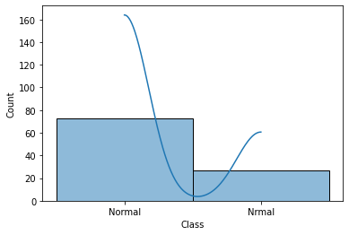

```python
#1E

sns.histplot(Normal_df['Class'], kde=True);
```

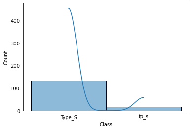

```python
sns.histplot(S_df['Class'], kde=True);
```

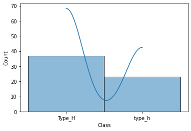

```python
sns.histplot(H_df['Class'], kde=True);
```

```python
#1E

Normal_df["Class"].value_counts()
```

```
Normal    73
Nrmal     27
Name: Class, dtype: int64
```

```python
S_df["Class"].value_counts()
```

```
Type_S    133
tp_s       17
Name: Class, dtype: int64
```

```python
H_df["Class"].value_counts()
```

```
Type_H    37
type_h    23
Name: Class, dtype: int64
```

There seems to be some data mismatch in all the 3 dataframes, "Normal" dataframe has 2 different "class" values and the same with H_df and S_df as shown in the Histogram and the Value counts

# 2. Data Preparation and Exploration

```python
#2A... Unifying all the variations

Normal_df.loc[:,'Class'] = Normal_df['Class'].apply(lambda x: "Normal" if x == "Nrmal" else x)
S_df.loc[:,'Class'] = S_df['Class'].apply(lambda x: "Type_S" if x == "tp_s" else x)
H_df.loc[:,'Class'] = H_df['Class'].apply(lambda x: "Type_H" if x == "type_h" else x)
```

```python
Normal_df["Class"].unique()
```

```
array(['Normal'], dtype=object)
```

```python
S_df["Class"].unique()
```

```
array(['Type_S'], dtype=object)
```

```python
H_df["Class"].unique()
```

```
array(['Type_H'], dtype=object)
```

```python
Normal_df.loc[:,"Class"] = Normal_df['Class'].astype('string')
S_df.loc[:,"Class"] = S_df['Class'].astype('string')
H_df.loc[:,"Class"] = H_df['Class'].astype('string')
```

```python
Normal_df.dtypes
```

```
P_incidence    float64
P_tilt         float64
L_angle        float64
S_slope        float64
P_radius       float64
S_Degree       float64
Class           string
dtype: object
```

```python
S_df.dtypes
```

```
P_incidence    float64
P_tilt         float64
L_angle        float64
S_slope        float64
P_radius       float64
S_Degree       float64
Class           string
dtype: object
```

```python
H_df.dtypes
```

```
P_incidence    float64
P_tilt         float64
L_angle        float64
S_slope        float64
P_radius       float64
S_Degree       float64
Class           string
dtype: object
```

```python
#2B Combining the 3 dataframes

final_df = pd.concat([Normal_df,S_df,H_df],axis=0)
```

```python
#2B.  As per the checkpoint, the combined dataframe's shape is 310 rows and 7 columns

final_df.shape
```

```
(310, 7)
```

```python
final_df
```

|  | P_incidence | P_tilt | L_angle | S_slope | P_radius | S_Degree | Class |
| --- | --- | --- | --- | --- | --- | --- | --- |
| 0 | 38.505273 | 16.964297 | 35.112814 | 21.540976 | 127.632875 | 7.986683 | Normal |
| 1 | 54.920858 | 18.968430 | 51.601455 | 35.952428 | 125.846646 | 2.001642 | Normal |
| 2 | 44.362490 | 8.945435 | 46.902096 | 35.417055 | 129.220682 | 4.994195 | Normal |
| 3 | 48.318931 | 17.452121 | 48.000000 | 30.866809 | 128.980308 | -0.910941 | Normal |
| 4 | 45.701789 | 10.659859 | 42.577846 | 35.041929 | 130.178314 | -3.388910 | Normal |
| ... | ... | ... | ... | ... | ... | ... | ... |
| 55 | 47.657730 | 13.277385 | 36.679985 | 34.380345 | 98.249781 | 6.273012 | Type_H |
| 56 | 43.349606 | 7.467469 | 28.065483 | 35.882137 | 112.776187 | 5.753277 | Type_H |
| 57 | 46.855781 | 15.351514 | 38.000000 | 31.504267 | 116.250917 | 1.662706 | Type_H |
| 58 | 43.203185 | 19.663146 | 35.000000 | 23.540039 | 124.846109 | -2.919076 | Type_H |
| 59 | 48.109236 | 14.930725 | 35.564683 | 33.178512 | 124.056452 | 7.947905 | Type_H |

310 rows × 7 columns

```python
final_df.describe().transpose()
```

|  | count | mean | std | min | 25% | 50% | 75% | max |
| --- | --- | --- | --- | --- | --- | --- | --- | --- |
| P_incidence | 310.0 | 60.496653 | 17.236520 | 26.147921 | 46.430294 | 58.691038 | 72.877696 | 129.834041 |
| P_tilt | 310.0 | 17.542822 | 10.008330 | -6.554948 | 10.667069 | 16.357689 | 22.120395 | 49.431864 |
| L_angle | 310.0 | 51.930930 | 18.554064 | 14.000000 | 37.000000 | 49.562398 | 63.000000 | 125.742385 |
| S_slope | 310.0 | 42.953831 | 13.423102 | 13.366931 | 33.347122 | 42.404912 | 52.695888 | 121.429566 |
| P_radius | 310.0 | 117.920655 | 13.317377 | 70.082575 | 110.709196 | 118.268178 | 125.467674 | 163.071041 |
| S_Degree | 310.0 | 26.296694 | 37.559027 | -11.058179 | 1.603727 | 11.767934 | 41.287352 | 418.543082 |

```python
#2C.  5 Random samples of the database with size = 30

final_r1 = final_df.sample(n=30)
final_r2 = final_df.sample(n=30)
final_r3 = final_df.sample(n=30)
final_r4 = final_df.sample(n=30)
final_r5 = final_df.sample(n=30)
```

```python
print("r1",final_r1["Class"].value_counts())
print("r2",final_r2["Class"].value_counts())
print("r3",final_r3["Class"].value_counts())
print("r4",final_r4["Class"].value_counts())
print("r5",final_r5["Class"].value_counts())
```

```
r1 Type_S    18
Normal     8
Type_H     4
Name: Class, dtype: Int64
r2 Normal    13
Type_S    11
Type_H     6
Name: Class, dtype: Int64
r3 Type_S    15
Normal     8
Type_H     7
Name: Class, dtype: Int64
r4 Type_S    17
Normal     7
Type_H     6
Name: Class, dtype: Int64
r5 Type_S    15
Normal    10
Type_H     5
Name: Class, dtype: Int64
```

```python
#2D... Feature wise percentage of null values

final_r1.isnull()
```

|  | P_incidence | P_tilt | L_angle | S_slope | P_radius | S_Degree | Class |
| --- | --- | --- | --- | --- | --- | --- | --- |
| 11 | False | False | False | False | False | False | False |
| 30 | False | False | False | False | False | False | False |
| 3 | False | False | False | False | False | False | False |
| 78 | False | False | False | False | False | False | False |
| 54 | False | False | False | False | False | False | False |
| 55 | False | False | False | False | False | False | False |
| 28 | False | False | False | False | False | False | False |
| 2 | False | False | False | False | False | False | False |
| 14 | False | False | False | False | False | False | False |
| 145 | False | False | False | False | False | False | False |
| 35 | False | False | False | False | False | False | False |
| 57 | False | False | False | False | False | False | False |
| 57 | False | False | False | False | False | False | False |
| 10 | False | False | False | False | False | False | False |
| 34 | False | False | False | False | False | False | False |
| 71 | False | False | False | False | False | False | False |
| 27 | False | False | False | False | False | False | False |
| 77 | False | False | False | False | False | False | False |
| 85 | False | False | False | False | False | False | False |
| 1 | False | False | False | False | False | False | False |
| 109 | False | False | False | False | False | False | False |
| 72 | False | False | False | False | False | False | False |
| 39 | False | False | False | False | False | False | False |
| 24 | False | False | False | False | False | False | False |
| 81 | False | False | False | False | False | False | False |
| 23 | False | False | False | False | False | False | False |
| 4 | False | False | False | False | False | False | False |
| 5 | False | False | False | False | False | False | False |
| 33 | False | False | False | False | False | False | False |
| 70 | False | False | False | False | False | False | False |

```python
final_r2.isnull()
```

|  | P_incidence | P_tilt | L_angle | S_slope | P_radius | S_Degree | Class |
| --- | --- | --- | --- | --- | --- | --- | --- |
| 42 | False | False | False | False | False | False | False |
| 129 | False | False | False | False | False | False | False |
| 36 | False | False | False | False | False | False | False |
| 67 | False | False | False | False | False | False | False |
| 29 | False | False | False | False | False | False | False |
| 37 | False | False | False | False | False | False | False |
| 12 | False | False | False | False | False | False | False |
| 50 | False | False | False | False | False | False | False |
| 64 | False | False | False | False | False | False | False |
| 35 | False | False | False | False | False | False | False |
| 53 | False | False | False | False | False | False | False |
| 15 | False | False | False | False | False | False | False |
| 19 | False | False | False | False | False | False | False |
| 97 | False | False | False | False | False | False | False |
| 15 | False | False | False | False | False | False | False |
| 132 | False | False | False | False | False | False | False |
| 113 | False | False | False | False | False | False | False |
| 66 | False | False | False | False | False | False | False |
| 68 | False | False | False | False | False | False | False |
| 147 | False | False | False | False | False | False | False |
| 70 | False | False | False | False | False | False | False |
| 112 | False | False | False | False | False | False | False |
| 44 | False | False | False | False | False | False | False |
| 125 | False | False | False | False | False | False | False |
| 52 | False | False | False | False | False | False | False |
| 139 | False | False | False | False | False | False | False |
| 60 | False | False | False | False | False | False | False |
| 101 | False | False | False | False | False | False | False |
| 127 | False | False | False | False | False | False | False |
| 38 | False | False | False | False | False | False | False |

```python
final_r3.isnull()
```

|  | P_incidence | P_tilt | L_angle | S_slope | P_radius | S_Degree | Class |
| --- | --- | --- | --- | --- | --- | --- | --- |
| 19 | False | False | False | False | False | False | False |
| 9 | False | False | False | False | False | False | False |
| 112 | False | False | False | False | False | False | False |
| 11 | False | False | False | False | False | False | False |
| 74 | False | False | False | False | False | False | False |
| 42 | False | False | False | False | False | False | False |
| 48 | False | False | False | False | False | False | False |
| 28 | False | False | False | False | False | False | False |
| 52 | False | False | False | False | False | False | False |
| 91 | False | False | False | False | False | False | False |
| 42 | False | False | False | False | False | False | False |
| 88 | False | False | False | False | False | False | False |
| 61 | False | False | False | False | False | False | False |
| 44 | False | False | False | False | False | False | False |
| 123 | False | False | False | False | False | False | False |
| 68 | False | False | False | False | False | False | False |
| 21 | False | False | False | False | False | False | False |
| 118 | False | False | False | False | False | False | False |
| 72 | False | False | False | False | False | False | False |
| 53 | False | False | False | False | False | False | False |
| 71 | False | False | False | False | False | False | False |
| 9 | False | False | False | False | False | False | False |
| 102 | False | False | False | False | False | False | False |
| 47 | False | False | False | False | False | False | False |
| 26 | False | False | False | False | False | False | False |
| 10 | False | False | False | False | False | False | False |
| 135 | False | False | False | False | False | False | False |
| 29 | False | False | False | False | False | False | False |
| 124 | False | False | False | False | False | False | False |
| 3 | False | False | False | False | False | False | False |

```python
final_r4.isnull()
```

|  | P_incidence | P_tilt | L_angle | S_slope | P_radius | S_Degree | Class |
| --- | --- | --- | --- | --- | --- | --- | --- |
| 29 | False | False | False | False | False | False | False |
| 12 | False | False | False | False | False | False | False |
| 39 | False | False | False | False | False | False | False |
| 129 | False | False | False | False | False | False | False |
| 81 | False | False | False | False | False | False | False |
| 52 | False | False | False | False | False | False | False |
| 147 | False | False | False | False | False | False | False |
| 100 | False | False | False | False | False | False | False |
| 19 | False | False | False | False | False | False | False |
| 31 | False | False | False | False | False | False | False |
| 27 | False | False | False | False | False | False | False |
| 0 | False | False | False | False | False | False | False |
| 115 | False | False | False | False | False | False | False |
| 69 | False | False | False | False | False | False | False |
| 24 | False | False | False | False | False | False | False |
| 47 | False | False | False | False | False | False | False |
| 135 | False | False | False | False | False | False | False |
| 26 | False | False | False | False | False | False | False |
| 80 | False | False | False | False | False | False | False |
| 18 | False | False | False | False | False | False | False |
| 35 | False | False | False | False | False | False | False |
| 0 | False | False | False | False | False | False | False |
| 35 | False | False | False | False | False | False | False |
| 15 | False | False | False | False | False | False | False |
| 37 | False | False | False | False | False | False | False |
| 17 | False | False | False | False | False | False | False |
| 109 | False | False | False | False | False | False | False |
| 36 | False | False | False | False | False | False | False |
| 84 | False | False | False | False | False | False | False |
| 8 | False | False | False | False | False | False | False |

```python
final_r5.isnull()
```

|  | P_incidence | P_tilt | L_angle | S_slope | P_radius | S_Degree | Class |
| --- | --- | --- | --- | --- | --- | --- | --- |
| 144 | False | False | False | False | False | False | False |
| 126 | False | False | False | False | False | False | False |
| 115 | False | False | False | False | False | False | False |
| 94 | False | False | False | False | False | False | False |
| 12 | False | False | False | False | False | False | False |
| 134 | False | False | False | False | False | False | False |
| 29 | False | False | False | False | False | False | False |
| 21 | False | False | False | False | False | False | False |
| 74 | False | False | False | False | False | False | False |
| 47 | False | False | False | False | False | False | False |
| 40 | False | False | False | False | False | False | False |
| 123 | False | False | False | False | False | False | False |
| 48 | False | False | False | False | False | False | False |
| 82 | False | False | False | False | False | False | False |
| 81 | False | False | False | False | False | False | False |
| 41 | False | False | False | False | False | False | False |
| 36 | False | False | False | False | False | False | False |
| 116 | False | False | False | False | False | False | False |
| 40 | False | False | False | False | False | False | False |
| 44 | False | False | False | False | False | False | False |
| 130 | False | False | False | False | False | False | False |
| 128 | False | False | False | False | False | False | False |
| 68 | False | False | False | False | False | False | False |
| 18 | False | False | False | False | False | False | False |
| 19 | False | False | False | False | False | False | False |
| 29 | False | False | False | False | False | False | False |
| 10 | False | False | False | False | False | False | False |
| 23 | False | False | False | False | False | False | False |
| 93 | False | False | False | False | False | False | False |
| 137 | False | False | False | False | False | False | False |

```python
#2D

print("P_incidence isnull",final_df['P_incidence'].isnull().values.any())

print("P_tilt isnull",final_df['P_tilt'].isnull().values.any())

print("L_angle isnull",final_df['L_angle'].isnull().values.any())

print("S_slope",final_df['S_slope'].isnull().values.any())

print("P_radius",final_df['P_radius'].isnull().values.any())

print("S_Degree",final_df['S_Degree'].isnull().values.any())
```

```
P_incidence isnull False
P_tilt isnull False
L_angle isnull False
S_slope False
P_radius False
S_Degree False
```

```python
#2D

print("P_incidence isnull %", ( final_df['P_incidence'].isnull().sum() / final_df['P_incidence'].count() ))

print("P_tilt isnull %",( final_df['P_tilt'].isnull().values.sum() / final_df['P_tilt'].count() ))

print("L_angle isnull %",( final_df['L_angle'].isnull().sum() / final_df['L_angle'].count() ))

print("S_slope %",( final_df['S_slope'].isnull().sum() / final_df['S_slope'].count() ))

print("P_radius %",( final_df['P_radius'].isnull().sum() / final_df['P_radius'].count() ))

print("S_Degree %",( final_df['S_Degree'].isnull().sum() / final_df['S_Degree'].count() ))
```

```
P_incidence isnull % 0.0
P_tilt isnull % 0.0
L_angle isnull % 0.0
S_slope % 0.0
P_radius % 0.0
S_Degree % 0.0
```

There are no null values at all in the dataframe for any of the features

```python
#2E.... 5 point summary of the new dataframe

final_df.describe()
```

|  | P_incidence | P_tilt | L_angle | S_slope | P_radius | S_Degree |
| --- | --- | --- | --- | --- | --- | --- |
| count | 310.000000 | 310.000000 | 310.000000 | 310.000000 | 310.000000 | 310.000000 |
| mean | 60.496653 | 17.542822 | 51.930930 | 42.953831 | 117.920655 | 26.296694 |
| std | 17.236520 | 10.008330 | 18.554064 | 13.423102 | 13.317377 | 37.559027 |
| min | 26.147921 | -6.554948 | 14.000000 | 13.366931 | 70.082575 | -11.058179 |
| 25% | 46.430294 | 10.667069 | 37.000000 | 33.347122 | 110.709196 | 1.603727 |
| 50% | 58.691038 | 16.357689 | 49.562398 | 42.404912 | 118.268178 | 11.767934 |
| 75% | 72.877696 | 22.120395 | 63.000000 | 52.695888 | 125.467674 | 41.287352 |
| max | 129.834041 | 49.431864 | 125.742385 | 121.429566 | 163.071041 | 418.543082 |

```python
final_df.describe().transpose()
```

|  | count | mean | std | min | 25% | 50% | 75% | max |
| --- | --- | --- | --- | --- | --- | --- | --- | --- |
| P_incidence | 310.0 | 60.496653 | 17.236520 | 26.147921 | 46.430294 | 58.691038 | 72.877696 | 129.834041 |
| P_tilt | 310.0 | 17.542822 | 10.008330 | -6.554948 | 10.667069 | 16.357689 | 22.120395 | 49.431864 |
| L_angle | 310.0 | 51.930930 | 18.554064 | 14.000000 | 37.000000 | 49.562398 | 63.000000 | 125.742385 |
| S_slope | 310.0 | 42.953831 | 13.423102 | 13.366931 | 33.347122 | 42.404912 | 52.695888 | 121.429566 |
| P_radius | 310.0 | 117.920655 | 13.317377 | 70.082575 | 110.709196 | 118.268178 | 125.467674 | 163.071041 |
| S_Degree | 310.0 | 26.296694 | 37.559027 | -11.058179 | 1.603727 | 11.767934 | 41.287352 | 418.543082 |

# 3. Data Analysis

```python
# 3A

final_df.corr()
```

|  | P_incidence | P_tilt | L_angle | S_slope | P_radius | S_Degree |
| --- | --- | --- | --- | --- | --- | --- |
| P_incidence | 1.000000 | 0.629199 | 0.717282 | 0.814960 | -0.247467 | 0.638743 |
| P_tilt | 0.629199 | 1.000000 | 0.432764 | 0.062345 | 0.032668 | 0.397862 |
| L_angle | 0.717282 | 0.432764 | 1.000000 | 0.598387 | -0.080344 | 0.533667 |
| S_slope | 0.814960 | 0.062345 | 0.598387 | 1.000000 | -0.342128 | 0.523557 |
| P_radius | -0.247467 | 0.032668 | -0.080344 | -0.342128 | 1.000000 | -0.026065 |
| S_Degree | 0.638743 | 0.397862 | 0.533667 | 0.523557 | -0.026065 | 1.000000 |

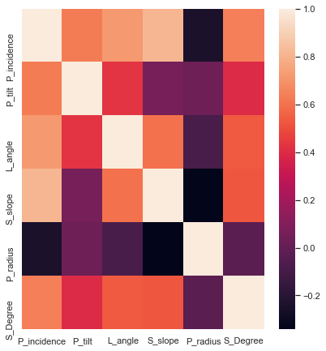

```python
# 3A

sns.heatmap(final_df.corr());
```

```python
#3B... Insignths on corelation

    #A Stronger postive corelation
      #P_incidence & S_slope - 0.81 have a stronger corelation followed by
      #P_incidence & L_angle - 0.71 and
      #P_incidence & S_Degree - 0.63 and
      #P_incidence & P_tilt - 0.62

    #B Weaker corelation
      #P_tilt and P_radius - 0.03 has a weaker corelation followed by
      #P_tilt and S_slope - 0.06
      #S_Degree and P_radius has a negative corelation of -0.02
```

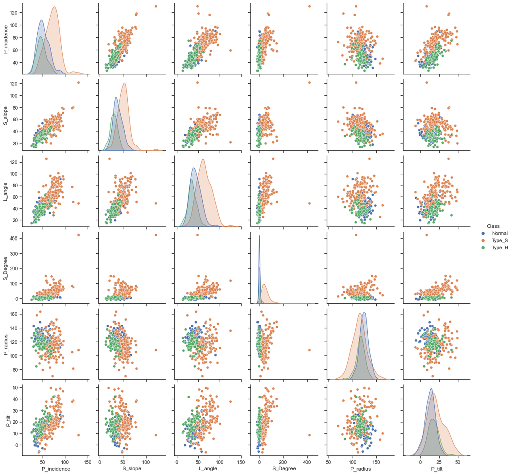

```python
#3C

sns.set(rc={'figure.figsize':(18.7,1200.27)})

sns. set(style="ticks", color_codes=True)

cols = final_df[['P_incidence','S_slope','L_angle','S_Degree', 'P_radius','P_tilt','Class']]

sns.pairplot(cols, hue='Class');
```

```python
Type_H (Green) & Normal (Blue) datapoints seem to be overlapping and pretty close to each other while the Type_S (Orange)
datapoints seem to be slightly away from the other two.  There seems to be quite a few outliers also in Type_S while the other
two class datapoints seem to be tightly coupled
```

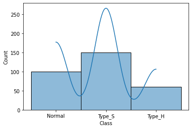

```python
sns.histplot(final_df['Class'], kde=True);
```

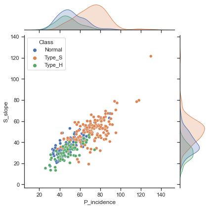

```python
sns.jointplot(x='P_incidence', y='S_slope', data=final_df, hue='Class');
```

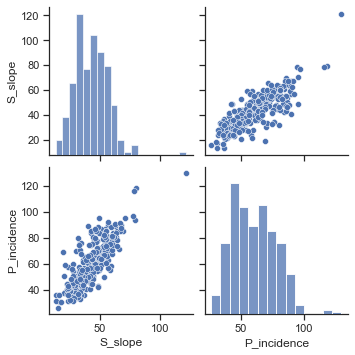

```python
sns.pairplot(final_df[['S_slope', 'P_incidence']]);
```

There is a relatively good co-relation between P_incidence & S_Slope when compared to other features...

There are some outliers in Type_S, but the other 2 classes datapoints (Normal & Type_H) look pretty tightly coupled.

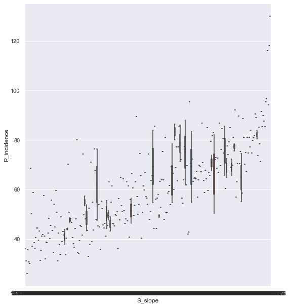

```python
sns.set(rc={'figure.figsize':(8.7,10.27)})

#sns.boxplot(final_df['P_incidence'], final_df['S_slope'], hue=final_df['Class']);

sns.boxplot(x = 'S_slope', y = 'P_incidence', data=final_df, palette="Set1");
```

```python
There are too many outliers between P_incidence & S_slope
```

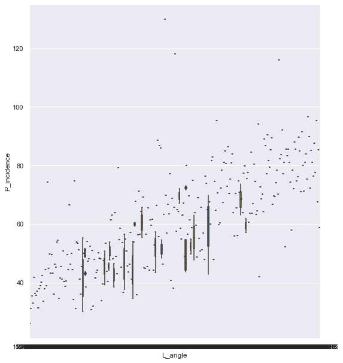

```python
sns.boxplot(x='L_angle', y='P_incidence', data=final_df, palette="Set1");
```

```python
There are too many outliers between P_incidence & L_angle
```

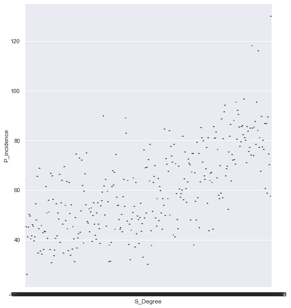

```python
sns.boxplot(x='S_Degree', y='P_incidence', data=final_df, palette="Set1");
```

```python
Here too, there are too many outliers between P_incidence & S_Degree
```

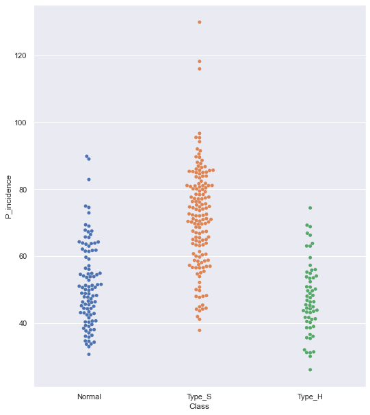

```python
sns.swarmplot(final_df['Class'], final_df['P_incidence']);
```

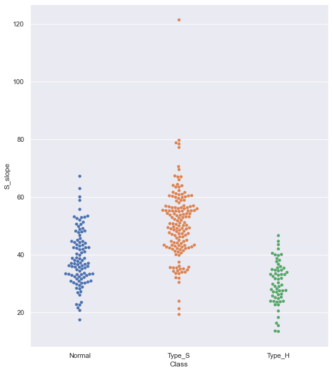

```python
sns.swarmplot(final_df['Class'], final_df['S_slope']);
```

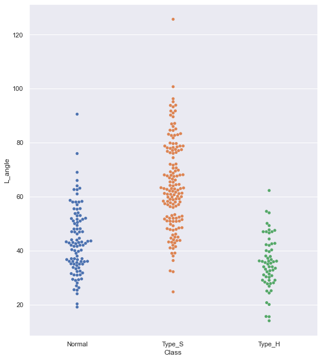

```python
sns.swarmplot(final_df['Class'], final_df['L_angle']);
```

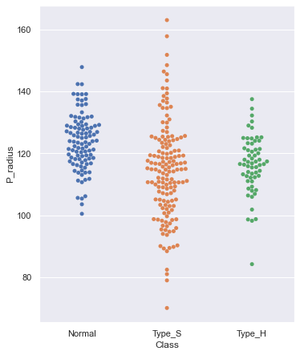

```python
sns.set(rc={'figure.figsize':(5.7,7.27)})
sns.swarmplot(final_df['Class'], final_df['P_radius']);
```

# 4. Model Building

```python
from sklearn.model_selection import train_test_split
from sklearn.neighbors import KNeighborsClassifier
import scipy.stats as stats

from sklearn.preprocessing import StandardScaler
from sklearn.preprocessing import MinMaxScaler
from sklearn.preprocessing import RobustScaler

from sklearn.metrics import roc_auc_score
from sklearn.model_selection import GridSearchCV

#fom scipy.stats import zscore
```

```python
final_df.describe()
```

|  | P_incidence | P_tilt | L_angle | S_slope | P_radius | S_Degree |
| --- | --- | --- | --- | --- | --- | --- |
| count | 310.000000 | 310.000000 | 310.000000 | 310.000000 | 310.000000 | 310.000000 |
| mean | 60.496653 | 17.542822 | 51.930930 | 42.953831 | 117.920655 | 26.296694 |
| std | 17.236520 | 10.008330 | 18.554064 | 13.423102 | 13.317377 | 37.559027 |
| min | 26.147921 | -6.554948 | 14.000000 | 13.366931 | 70.082575 | -11.058179 |
| 25% | 46.430294 | 10.667069 | 37.000000 | 33.347122 | 110.709196 | 1.603727 |
| 50% | 58.691038 | 16.357689 | 49.562398 | 42.404912 | 118.268178 | 11.767934 |
| 75% | 72.877696 | 22.120395 | 63.000000 | 52.695888 | 125.467674 | 41.287352 |
| max | 129.834041 | 49.431864 | 125.742385 | 121.429566 | 163.071041 | 418.543082 |

```python
final_df.groupby(["Class"]).count()
```

| Class | P_incidence | P_tilt | L_angle | S_slope | P_radius | S_Degree |
| --- | --- | --- | --- | --- | --- | --- |
| Normal | 100 | 100 | 100 | 100 | 100 | 100 |
| Type_H | 60 | 60 | 60 | 60 | 60 | 60 |
| Type_S | 150 | 150 | 150 | 150 | 150 | 150 |

```python
# 4A..... Splitting Data into X (Independent variables) & Y (dependent variable - Class)

X = final_df.drop('Class',axis=1)     # Predictor class
y = final_df['Class']   # Predicted class (Normal, Type_S, Type_H)
```

```python
y.value_counts()
```

```
Type_S    150
Normal    100
Type_H     60
Name: Class, dtype: Int64
```

```python
X.describe()
```

|  | P_incidence | P_tilt | L_angle | S_slope | P_radius | S_Degree |
| --- | --- | --- | --- | --- | --- | --- |
| count | 310.000000 | 310.000000 | 310.000000 | 310.000000 | 310.000000 | 310.000000 |
| mean | 60.496653 | 17.542822 | 51.930930 | 42.953831 | 117.920655 | 26.296694 |
| std | 17.236520 | 10.008330 | 18.554064 | 13.423102 | 13.317377 | 37.559027 |
| min | 26.147921 | -6.554948 | 14.000000 | 13.366931 | 70.082575 | -11.058179 |
| 25% | 46.430294 | 10.667069 | 37.000000 | 33.347122 | 110.709196 | 1.603727 |
| 50% | 58.691038 | 16.357689 | 49.562398 | 42.404912 | 118.268178 | 11.767934 |
| 75% | 72.877696 | 22.120395 | 63.000000 | 52.695888 | 125.467674 | 41.287352 |
| max | 129.834041 | 49.431864 | 125.742385 | 121.429566 | 163.071041 | 418.543082 |

```python
#4B

# Split X and y into training and test set in 80:20 ratio

X_train, X_test, y_train, y_test = train_test_split(X, y, test_size=0.20, random_state=1)
```

```python
# 4C.... choosing 5 neighbours

NNH = KNeighborsClassifier(n_neighbors= 5, weights = 'distance' )
```

```python
# 4C....

NNH.fit(X_train, y_train)
```

```
KNeighborsClassifier(weights='distance')
```

```python
# For every test data point, predict it's label based on 5 nearest neighbours in this model. The majority class will
# be assigned to the test data point

predicted_labels = NNH.predict(X_test)
NNH.score(X_test, y_test)
```

```
0.8387096774193549
```

```python
NNH.score(X_train, y_train)
```

```
1.0
```

```python
print(predicted_labels)
```

```
['Normal' 'Type_S' 'Type_S' 'Normal' 'Type_S' 'Normal' 'Normal' 'Type_S'
 'Type_S' 'Type_S' 'Type_S' 'Normal' 'Normal' 'Type_H' 'Type_H' 'Type_S'
 'Type_H' 'Type_H' 'Type_S' 'Normal' 'Type_S' 'Type_S' 'Normal' 'Type_S'
 'Normal' 'Type_S' 'Type_S' 'Type_S' 'Normal' 'Type_S' 'Type_S' 'Type_S'
 'Type_H' 'Type_S' 'Normal' 'Type_S' 'Normal' 'Type_H' 'Type_S' 'Type_S'
 'Type_S' 'Normal' 'Normal' 'Normal' 'Type_S' 'Type_H' 'Type_H' 'Type_H'
 'Type_S' 'Normal' 'Type_S' 'Type_H' 'Normal' 'Type_S' 'Normal' 'Normal'
 'Normal' 'Type_S' 'Type_H' 'Type_S' 'Normal' 'Type_S']
```

```python
print(X_train)
```

```
     P_incidence     P_tilt    L_angle    S_slope    P_radius   S_Degree
57     46.855781  15.351514  38.000000  31.504267  116.250917   1.662706
0      38.505273  16.964297  35.112814  21.540976  127.632875   7.986683
32     85.352315  15.844910  71.668660  69.507405  124.419787  76.020603
108    95.382596  24.822631  95.157633  70.559965   89.307547  57.660841
62     39.358705   7.011262  37.000000  32.347443  117.818760   1.904048
..           ...        ...        ...        ...         ...        ...
103   115.923261  37.515436  76.800000  78.407825  104.698603  81.198927
5      40.250200  13.921907  25.124950  26.328293  130.327871   2.230652
72     53.683380  13.447022  41.584297  40.236358  113.913703   2.737035
135    71.241764   5.268270  85.999584  65.973493  110.703107  38.259864
37     49.828135  16.736435  28.000000  33.091700  121.435558   1.913307

[248 rows x 6 columns]
```

```
Confusion Matrix
```

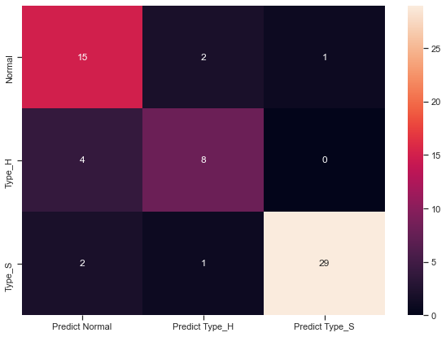

```python
# calculate accuracy measures and confusion matrix
from sklearn import metrics

print("Confusion Matrix")

cm=metrics.confusion_matrix(y_test, predicted_labels, labels=["Normal", "Type_H", "Type_S"])

df_cm = pd.DataFrame(cm, index = [i for i in ["Normal", "Type_H", "Type_S"]],
                  columns = [i for i in ["Predict Normal","Predict Type_H", "Predict Type_S"]])
plt.figure(figsize = (10,7))
sns.heatmap(df_cm, annot=True)
```

```python
print(y_test.count())
print(len(predicted_labels))
```

```
62
62
```

```python
Precision = ( np.diag(cm) / np.sum(cm, axis = 0))
Recall    = ( np.diag(cm) / np.sum(cm, axis = 1))

print("KNN - Accuracy ",metrics.accuracy_score(y_test, predicted_labels))
print("KNN - Precision",metrics.precision_score(y_test, predicted_labels, average='weighted'))
print("KNN - Recall   ",metrics.recall_score(y_test, predicted_labels, average='weighted'))
print("KNN - F1 score ",metrics.f1_score(y_test, predicted_labels, average='weighted'))
#print("KNN - ROC      ",metrics.roc_auc_score(y_test, predicted_labels, average="weighted", multi_class='ovr'))
```

```
KNN - Accuracy  0.8387096774193549
KNN - Precision 0.8470604664153051
KNN - Recall    0.8387096774193549
KNN - F1 score  0.8407978032915824
```